# How do marriages look like?

## An analysis of how different factors are related to marriage and divorce.

By Yiran Mo, Chenxi Wu, Keyi Zhong and Zac Zhu

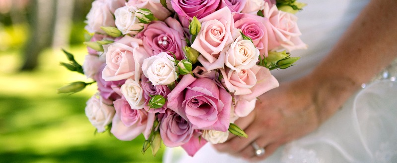

marriage

**Shiny URL:** [How do marriages look like?](https://keyizhong.shinyapps.io/pineapple-tribe-final/)

This app gives you a chance to have visualization of marriage/divorce rate by filter out the factors you want to know more about.

**Our Data**

[Data](https://github.com/fivethirtyeight/data/tree/master/marriage) we worked with is from fivethirtyeight.com. Source of all data is Decennial Census (from 1960 to 2000), and American Community Survey (from 2001-2012), via [IPUMS USA](https://usa.ipums.org/usa/cite.shtml). This data contains some useful data of marriage and divorce rate across different factors including sex, age, race, education level, region (in the U.S.) and income level. Notice that some of the factors mentioned above might not included in the marriage/divorce data set. Data of divorce rate only contains age, education level and income level. A thing to keep in mind: Form 1960 to 2000, the data was presented every 10 years, but since 2000, the data is presented yearly.

Please read the summary page for more insights of marriage and divorce.